# Data Exploration on Ford GoBike Trips

## Preliminary Wrangling

> This dataset contains information about individual rides made in Ford GoBike bike-sharing system in February 2019, covering the greater San Francisco Bay area.

```python
# import all packages and set plots to be embedded inline
import numpy as np
import pandas as pd
import matplotlib.pyplot as plt
import seaborn as sb

%matplotlib inline
```

```python
# read data into a dataframe
df = pd.read_csv('201902-fordgobike-tripdata.csv')
```

### Assessing the Data

```python
# display first five records
df.head()
```

|  | duration_sec | start_time | end_time | start_station_id | start_station_name | start_station_latitude | start_station_longitude | end_station_id | end_station_name | end_station_latitude | end_station_longitude | bike_id | user_type | member_birth_year | member_gender | bike_share_for_all_trip |
| --- | --- | --- | --- | --- | --- | --- | --- | --- | --- | --- | --- | --- | --- | --- | --- | --- |
| 0 | 52185 | 2019-02-28 17:32:10.1450 | 2019-03-01 08:01:55.9750 | 21.0 | Montgomery St BART Station (Market St at 2nd St) | 37.789625 | -122.400811 | 13.0 | Commercial St at Montgomery St | 37.794231 | -122.402923 | 4902 | Customer | 1984.0 | Male | No |
| 1 | 42521 | 2019-02-28 18:53:21.7890 | 2019-03-01 06:42:03.0560 | 23.0 | The Embarcadero at Steuart St | 37.791464 | -122.391034 | 81.0 | Berry St at 4th St | 37.775880 | -122.393170 | 2535 | Customer | NaN | NaN | No |
| 2 | 61854 | 2019-02-28 12:13:13.2180 | 2019-03-01 05:24:08.1460 | 86.0 | Market St at Dolores St | 37.769305 | -122.426826 | 3.0 | Powell St BART Station (Market St at 4th St) | 37.786375 | -122.404904 | 5905 | Customer | 1972.0 | Male | No |
| 3 | 36490 | 2019-02-28 17:54:26.0100 | 2019-03-01 04:02:36.8420 | 375.0 | Grove St at Masonic Ave | 37.774836 | -122.446546 | 70.0 | Central Ave at Fell St | 37.773311 | -122.444293 | 6638 | Subscriber | 1989.0 | Other | No |
| 4 | 1585 | 2019-02-28 23:54:18.5490 | 2019-03-01 00:20:44.0740 | 7.0 | Frank H Ogawa Plaza | 37.804562 | -122.271738 | 222.0 | 10th Ave at E 15th St | 37.792714 | -122.248780 | 4898 | Subscriber | 1974.0 | Male | Yes |

```python
# display the shape
df.shape
```

```
(183412, 16)
```

```python
# display info
df.info()
```

```
<class 'pandas.core.frame.DataFrame'>
RangeIndex: 183412 entries, 0 to 183411
Data columns (total 16 columns):
 #   Column                   Non-Null Count   Dtype
---  ------                   --------------   -----
 0   duration_sec             183412 non-null  int64
 1   start_time               183412 non-null  object
 2   end_time                 183412 non-null  object
 3   start_station_id         183215 non-null  float64
 4   start_station_name       183215 non-null  object
 5   start_station_latitude   183412 non-null  float64
 6   start_station_longitude  183412 non-null  float64
 7   end_station_id           183215 non-null  float64
 8   end_station_name         183215 non-null  object
 9   end_station_latitude     183412 non-null  float64
 10  end_station_longitude    183412 non-null  float64
 11  bike_id                  183412 non-null  int64
 12  user_type                183412 non-null  object
 13  member_birth_year        175147 non-null  float64
 14  member_gender            175147 non-null  object
 15  bike_share_for_all_trip  183412 non-null  object
dtypes: float64(7), int64(2), object(7)
memory usage: 22.4+ MB
```

```python
# descriptive statistics
df.describe()
```

|  | duration_sec | start_station_id | start_station_latitude | start_station_longitude | end_station_id | end_station_latitude | end_station_longitude | bike_id | member_birth_year |
| --- | --- | --- | --- | --- | --- | --- | --- | --- | --- |
| count | 183412.000000 | 183215.000000 | 183412.000000 | 183412.000000 | 183215.000000 | 183412.000000 | 183412.000000 | 183412.000000 | 175147.000000 |
| mean | 726.078435 | 138.590427 | 37.771223 | -122.352664 | 136.249123 | 37.771427 | -122.352250 | 4472.906375 | 1984.806437 |
| std | 1794.389780 | 111.778864 | 0.099581 | 0.117097 | 111.515131 | 0.099490 | 0.116673 | 1664.383394 | 10.116689 |
| min | 61.000000 | 3.000000 | 37.317298 | -122.453704 | 3.000000 | 37.317298 | -122.453704 | 11.000000 | 1878.000000 |
| 25% | 325.000000 | 47.000000 | 37.770083 | -122.412408 | 44.000000 | 37.770407 | -122.411726 | 3777.000000 | 1980.000000 |
| 50% | 514.000000 | 104.000000 | 37.780760 | -122.398285 | 100.000000 | 37.781010 | -122.398279 | 4958.000000 | 1987.000000 |
| 75% | 796.000000 | 239.000000 | 37.797280 | -122.286533 | 235.000000 | 37.797320 | -122.288045 | 5502.000000 | 1992.000000 |
| max | 85444.000000 | 398.000000 | 37.880222 | -121.874119 | 398.000000 | 37.880222 | -121.874119 | 6645.000000 | 2001.000000 |

```python
# check missing data of features to be explored
print(df.member_gender.isnull().sum())
print(df.member_birth_year.isnull().sum())
```

```
8265
8265
```

```python
# check for duplicates
df.duplicated().sum()
```

```
0
```

### What is the structure of your dataset?

> The dataset has 16 columns and 183412 records. Some data quality issues need to be addressed, such as missing data and incorrect data types.

### What is/are the main feature(s) of interest in your dataset?

> The main features of interest will be the trip's duration and start time.

### What features in the dataset do you think will help support your investigation into your feature(s) of interest?

> Features containing user information / membership will be explored. These are the user type, gender, birth year, and whether the trip was taken under the "Bike Share for All" program.

### Cleaning the Data

```python
# create a copy of the dataframe to be used for cleaning
bike = df.copy()
```

#### Deal with missing data

It is not possible to obtain the missing data for birth year and gender so I decided to drop the null records.

```python
bike.dropna(subset=['member_birth_year'], inplace=True)
bike.dropna(subset=['member_gender'], inplace=True)
```

#### Deal with incorrect data types

Convert data type of relevant features

```python
bike['start_time'] = pd.to_datetime(bike['start_time'])
bike['member_birth_year'] = bike.member_birth_year.astype(int)
bike['user_type'] = bike.user_type.astype('category')
bike['member_gender'] = bike.member_gender.astype('category')
bike['bike_share_for_all_trip'] = bike.bike_share_for_all_trip.astype('category')
```

#### Extract the hour and day from trip's start time

The start_time column will be split into time of day and day of week values.

```python
bike['start_hour'] = bike['start_time'].dt.hour
bike['start_day'] = bike['start_time'].dt.dayofweek
```

#### Convert birth year to age

It makes more sense to perform analysis on age rather than birth year. The values will be calculated based on the year 2019.

```python
bike['member_age'] = 2019 - bike.member_birth_year
```

#### Drop columns that won't be used in the analysis

```python
bike = bike[['duration_sec', 'user_type', 'member_gender', 'bike_share_for_all_trip', 'start_hour', 'start_day', 'member_age']]
```

```python
bike.head(1)
```

|  | duration_sec | user_type | member_gender | bike_share_for_all_trip | start_hour | start_day | member_age |
| --- | --- | --- | --- | --- | --- | --- | --- |
| 0 | 52185 | Customer | Male | No | 17 | 3 | 35 |

```python
bike.info()
```

```
<class 'pandas.core.frame.DataFrame'>
Int64Index: 175147 entries, 0 to 183411
Data columns (total 7 columns):
 #   Column                   Non-Null Count   Dtype
---  ------                   --------------   -----
 0   duration_sec             175147 non-null  int64
 1   user_type                175147 non-null  category
 2   member_gender            175147 non-null  category
 3   bike_share_for_all_trip  175147 non-null  category
 4   start_hour               175147 non-null  int64
 5   start_day                175147 non-null  int64
 6   member_age               175147 non-null  int64
dtypes: category(3), int64(4)
memory usage: 7.2 MB
```

## Univariate Exploration

> Each of the main features of interest (duration, time of day, day of week) and supporting features (user type, gender, age, and "Bike Share for All" trip) will be explored.

### Duration in seconds

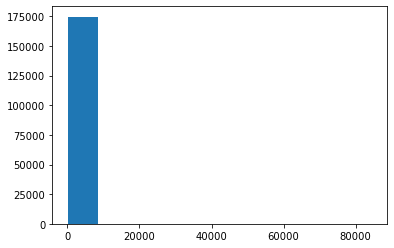

```python
plt.hist(data=bike, x='duration_sec');
```

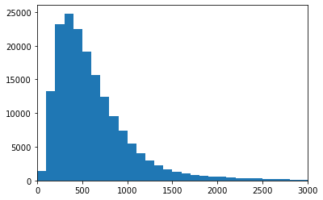

```python
bins = np.arange(0, bike.duration_sec.max()+100, 100)
plt.hist(data=bike, x='duration_sec', bins=bins);
plt.xlim(0,3000);
```

The data has a highly skewed distribution and a long tail which suggests that a log transform may be necessary.

```python
# Transform the describe() to a scale of log10
np.log10(bike['duration_sec'].describe())
```

```
count    5.243403
mean     2.847703
std      3.215270
min      1.785330
25%      2.509203
50%      2.707570
75%      2.897077
max      4.927103
Name: duration_sec, dtype: float64
```

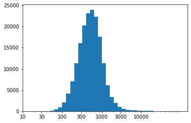

```python
# Get the ticks for bins
bins = 10 ** np.arange(1.7, 5+0.1, 0.1)

# Generate the x-ticks
ticks = [10, 30, 100, 300, 1000, 3000, 10000]
# Convert ticks into string values, to be displaye dlong the x-axis
labels = ['{}'.format(v) for v in ticks]

# Plot the histogram
plt.hist(data=bike, x='duration_sec', bins=bins);
plt.xscale('log')

# Apply x-ticks
plt.xticks(ticks, labels);
```

### Time of day

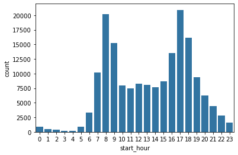

```python
base_color = sb.color_palette()[0]
sb.countplot(data=bike, x='start_hour', color=base_color);
```

Although the variable is numeric, its values are discrete and thus a bar chart is more appropriate. The distributiion is bimodal and has peaks at 8:00 and 17:00. This probably coincides with peak hours on weekdays, which we'll investigate in the next plot. There are also noticeably very few trips taken from midnight until dawn.

### Day of week

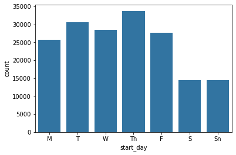

```python
g = sb.countplot(data=bike, x='start_day', color=base_color);
g.set_xticklabels(['M','T','W','Th','F','S','Sn']);
```

Majority of the trips were taken on weekdays. This explains the peaks in start_hour variable.

### User type

```python
def plot_prop(col, col_name):
    # Count the frequency of unique values
    type_counts = col.value_counts()

    # Get the unique values in decreasing order of frequency
    type_order = type_counts.index

    # Returns the sum of all not-null values
    n_col = col.value_counts().sum()

    # Return the highest frequency
    max_type_count = type_counts[0]

    # Return the maximum proportion
    max_prop = max_type_count / n_col

    # Produce a set of evenly spaced proportioned values
    tick_props = np.arange(0, max_prop, 0.1)

    # Use a list comprehension to create tick_names that we will apply to the tick labels
    tick_names = ['{:0.2f}'.format(v) for v in tick_props]

    # Plot the data
    sb.countplot(data=bike, x=col_name, color=sb.color_palette()[0], order=type_order);

    # Change the tick locations and labels
    plt.yticks(tick_props * n_col, tick_names)
    plt.ylabel('proportion');
```

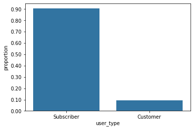

```python
plot_prop(bike['user_type'], 'user_type')
```

Subscribers are entitled to unlimited rides so it isn't susprising for them to take more trips, which account for about 90% of the data.

### Age

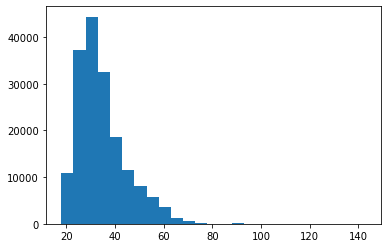

```python
plt.hist(data=bike, x='member_age', bins=np.arange(bike.member_age.min(),bike.member_age.max()+5,5));
```

The data has a skewed distribution with outliers at approximately the 90 mark. Although it is possible to reach an age over 80, it seems unlikely for users in this age group to still use the bike sharing service. There is no possibility to verify these values at the moment, so I decided to drop the affected rows.

```python
bike = bike[bike.member_age < 80]
```

```python
(bike.member_age > 80).sum()
```

```
0
```

```python
# save df to csv to be used for explanatory analysis
bike.to_csv('bike.csv', index=False);
```

### Gender

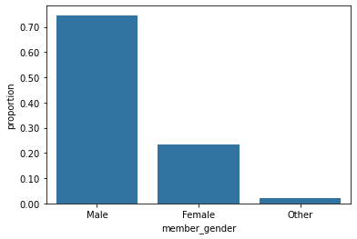

```python
plot_prop(bike['member_gender'], 'member_gender')
```

Approximately 75% of users are male, 23% female, the rest are unspecified.

### Bike Share for All

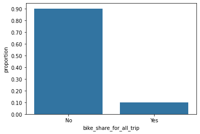

```python
plot_prop(bike['bike_share_for_all_trip'], 'bike_share_for_all_trip')
```

Majority of the trips (about 90%) taken weren't eligible for the "Bike Share for All" program.

### Of the features you investigated, were there any unusual distributions? Did you perform any operations on the data to tidy, adjust, or change the form of the data? If so, why did you do this?

> The age variable has unusual points above the 80 mark. These were difficult to clean, therefore they were ultimately dropped.

## Bivariate Exploration

> In this section, the main features will be compared with each other and to each of the supporting features.

### Duration vs Time of Day

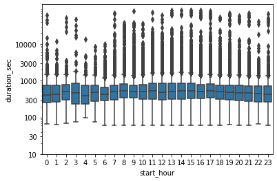

```python
sb.boxplot(x='start_hour', y='duration_sec', data=bike, color=base_color)
plt.yscale('log');
plt.yticks(ticks, labels);
```

The average trip duration didn't change that much with the time of day.

### Duration vs Day of Week

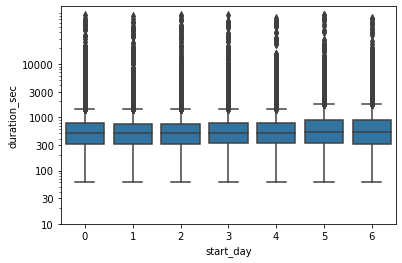

```python
sb.boxplot(x='start_day', y='duration_sec', data=bike, color=base_color)
plt.yscale('log');
plt.yticks(ticks, labels);
```

The average trip duration didn't change with the day of the week.

### Duration vs User Type

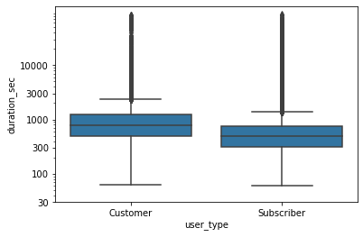

```python
ticks = [30, 100, 300, 1000, 3000, 10000]
labels = ['{}'.format(v) for v in ticks]

sb.boxplot(x='user_type', y='duration_sec', data=bike, color=base_color)
plt.yscale('log');
plt.yticks(ticks, labels);
```

The data suggests that regular customers take less but slightly longer trips than subscribers do. This is possibly due to customers maximizing each trip (as each trip is charged in 30 minute increments), while subscribers can take unlimited shorter trips without additional costs. Both distributions are skewed and have a bunch of outliers, which I think are valid data points since day passes are also offered.

### Duration vs Bike Share for All

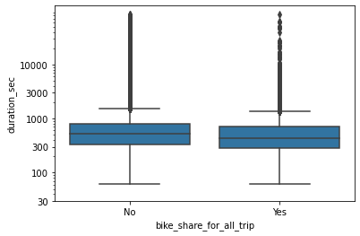

```python
sb.boxplot(x='bike_share_for_all_trip', y='duration_sec', data=bike, color=base_color)
plt.yscale('log');
plt.yticks(ticks, labels);
```

The distributions have a very slight difference. Discounted membership doesn't seem to have a significant impact on a trip's duration.

### Duration vs Gender

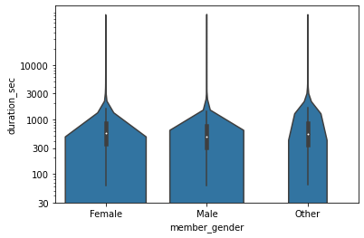

```python
sb.violinplot(x='member_gender', y='duration_sec', data=bike, color=base_color);
plt.yscale('log');
plt.yticks(ticks, labels);
```

The plot for 'Other' is noticeably thinner than the rest, however this is due to the small number of data points. Looking at the median and interquartile range, the gender doesn't have a significant effect on the duration.

### Duration vs Age

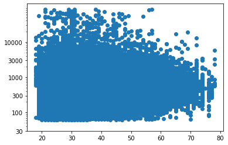

```python
plt.scatter(data=bike, x='member_age', y='duration_sec');
plt.yscale('log');
plt.yticks(ticks, labels);
```

The graph is overplotted so the transparency will have to be adjusted.

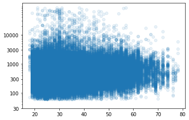

```python
plt.scatter(data=bike, x='member_age', y='duration_sec',alpha=0.1);
plt.yscale('log');
plt.yticks(ticks, labels);
```

There seems to be no correlation between the duration and age.

### Time of day vs User type

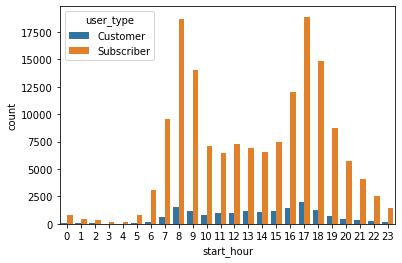

```python
g = sb.countplot(data=bike, x='start_hour', hue='user_type');
```

Both plots have bimodal distributions with peaks on the same hour. The subscriber plot has sharper peaks than the customer plot. Regular customers tend to use the service more throughout the day while subscribers mostly use it during peak hours. This suggests that user type affects the frequency of trips taken with respect to the time of day.

### Time of day vs Bike Share for All

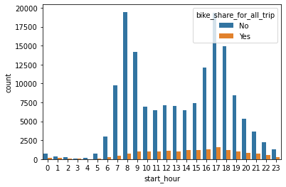

```python
g = sb.countplot(data=bike, x='start_hour', hue='bike_share_for_all_trip');
```

The distributions look very different. For non-discounted trips, there are two distinct peaks whereas for discounted trips, the frequency gradually increased from where the first peak should have been up to the second peak. This suggests that non-discounted trips are only taken mostly during peak hours while discounted trips are dispersed throughout the day.

### Time of day vs Gender

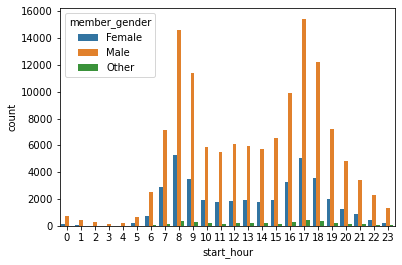

```python
g = sb.countplot(data=bike, x='start_hour', hue='member_gender');
```

The plots look very similar, thus gender doesn't have no significant impact on the time of day.

### Time of day vs Age

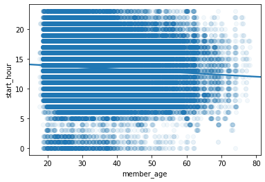

```python
sb.regplot(data = bike, x = 'member_age', y = 'start_hour', truncate=False, x_jitter=0.3, scatter_kws={'alpha':1/20});
```

Age and time of day are not correlated.

### Day of week vs User type

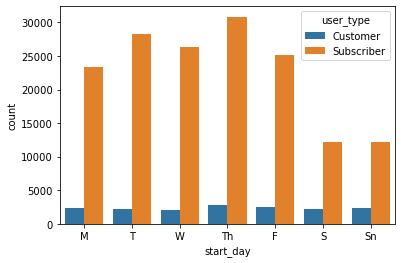

```python
g = sb.countplot(data=bike, x='start_day', hue='user_type');
g.set_xticklabels(['M','T','W','Th','F','S','Sn']);
```

If we look closely, both user types have most trips on Thursdays, which agrees with the result from the previous section. One huge difference between the two is the frequency of trips taken on weekdays vs weekends. Customers have taken a fairly constant number of trips daily whereas subscribers have taken most of the trips on weekdays.

### Day of week vs Bike Share for All

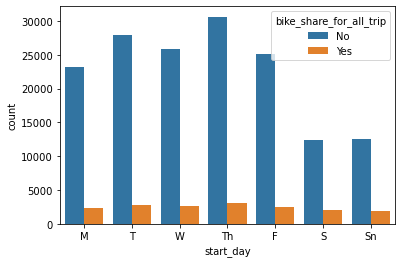

```python
g = sb.countplot(data=bike, x='start_day', hue='bike_share_for_all_trip');
g.set_xticklabels(['M','T','W','Th','F','S','Sn']);
```

The results are quite similar to the previous plot. In this case, non-discounted trips were taken more frequently on weekdays while discounted ones were taken almost constantly throughout the week.

### Day of week vs Gender

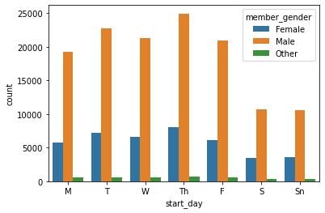

```python
g = sb.countplot(data=bike, x='start_day', hue='member_gender');
g.set_xticklabels(['M','T','W','Th','F','S','Sn']);
```

All genders have taken more trips on weekdays with the highest count on Thursday.

### Day of week vs Age

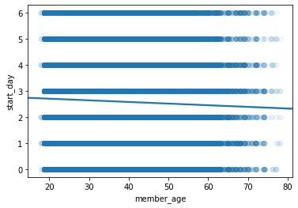

```python
sb.regplot(data = bike, x = 'member_age', y = 'start_day', truncate=False, x_jitter=0.3, scatter_kws={'alpha':1/20});
```

Age doesn't have an impact on the trips taken per day.

### Gender vs User type

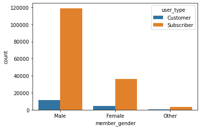

```python
# Count the frequency of unique values
type_counts = bike['member_gender'].value_counts()

# Get the unique values in decreasing order of frequency
type_order = type_counts.index
sb.countplot(data=bike, x='member_gender', hue='user_type',order=type_order);
```

The highest number of trips were taken by male subscribers. Gender doesn't seem to affect the proportion between customers and subscribers.

### Gender vs Bike Share for All

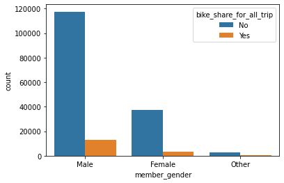

```python
sb.countplot(data=bike, x='member_gender', hue='bike_share_for_all_trip',order=type_order);
```

Gender doesn't seem to affect a user's eligibility for Bike Share for All program.

### Did you observe any interesting relationships between the other features (not the main feature(s) of interest)?

> The highest number of trips were taken by male subscribers. Gender doesn't seem to have a significant impact on the proportion between user types and on a user's eligibility for Bike Share for All program.

## Multivariate Exploration

### Duration vs User Type vs Gender

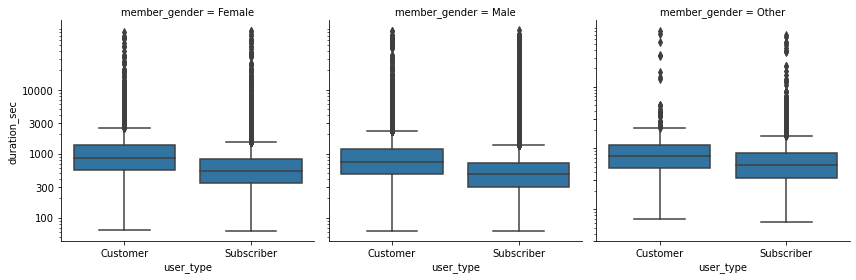

```python
g = sb.FacetGrid(data = bike, col = 'member_gender', height = 4);
g.map(sb.boxplot, 'user_type', 'duration_sec', order=['Customer','Subscriber']);
plt.yscale('log');
plt.yticks(ticks, labels);
```

Customers consistently took longer trips regardless of the gender. This agrees with the results from previous bivariate explorations.

## Duration vs Bike Share for All vs Gender

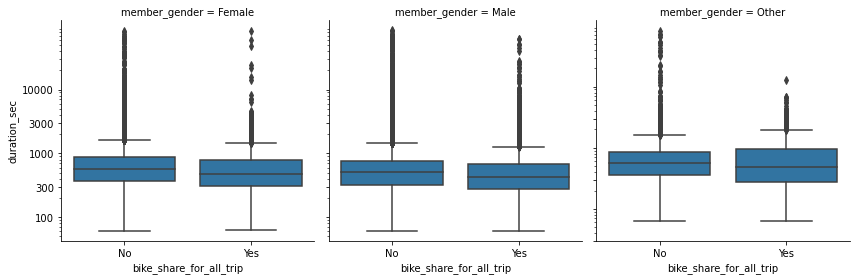

```python
g = sb.FacetGrid(data = bike, col = 'member_gender', height = 4);
g.map(sb.boxplot, 'bike_share_for_all_trip', 'duration_sec',order=['No','Yes']);
plt.yscale('log');
plt.yticks(ticks, labels);
```

Unspecified genders had a different effect on the relationship between the duration and Bike Share for All variable. However, this may be insignificant as other genders only account for 2% of the data.

### Talk about some of the relationships you observed in this part of the investigation. Were there features that strengthened each other in terms of looking at your feature(s) of interest?

> Customers consistently took longer trips regardless of the gender. This agrees the results from previous bivariate explorations and reinforces the relationship between user type and duration. Unspecified genders had a different effect on the relationship between the duration and Bike Share for All variable. However, this may be insignificant as other genders only account for 2% of the data.

### Were there any interesting or surprising interactions between features?

> It is interesting to see how the proportion of gender data affects the distribution of duration versus Bike Share for All.